# Salud Oral: Tratamiento Convencional y No Convenional en adulto mayor

Bastián Chávez

5 de julio de 2018

## I. Antecedentes

### Formulación

**Propósito**: Evaluar el impacto de estrategias convencionales versus mínimamente invasivas en la adherencia a tratamiento protésico y en calidad de vida de adultos mayores de la Región Metropolitana de Santiago, Chile.

**Método**

- Durante los años 2012 al 2016, una cohorte de 2.134 adultos mayores consultó por atención odontológica en servicios públicos y privados de la región metropolitana en busca de soluciones protésicas. Todos los interesados firmaron los documentos de consentimiento informado de cada institución Los pacientes fueron tratados de acuerdo a los protocolos de atención institucionales.
- Grupo A estrategias mínimamente invasivas (remoción incompleta de caries y restauración pos-endodóntica) Grupo B estrategias convencionales (remoción completa de caries y Protesis fija). Todos los pacientes eran ASA I y II.
- Se les clasificó según el índice de Eichner, que clasifica en A(1), B(2) y C(3), que representan las categorías oclusales. Las arcadas clasificadas como A tienen contacto oclusal en las cuatro áreas masticatorias; las arcadas clasificadas como B tienen contacto oclusal pero no en todas las áreas masticatorias; y las arcadas clasificadas como C no presentan ningún contacto oclusal aunque pueden quedar dientes remanentes.
- Al inicio y término del tratamiento se les aplicó el Índice Geriátrico de Salud Oral (GOHAI) y se observó la adherencia al tratamiento protésico.

### Diccionario de varibles

| Variable Name | Definición |
| --- | --- |
| `Genero` | Masculino=0 / Femenino=1 |
| `Edad` | Edad del paciente |
| `Año` | Año de la intervención |
| `Grupo` | A: Mínimamente invasiva / B: Convensional |
| `Eichner` | 1: A / 2: B / 3: C |
| `GI (Gohai Inicial)` | Bajo: -de 50 / Moderado: entre 51 y 56 / Alto: entre 57 y 60 |
| `GI (Gohai Final)` | Bajo: -de 50 / Moderado: entre 51 y 56 / Alto: entre 57 y 60 |
| `Adh1` | Adhesión inicial al uso protésico |
| `Adh2` | Adhesión final al uso protésico |

#### Sumario de variables

```r
load("Convencional_rec.RData")
summary(Convencional)
```

```
##        X         Genero       Edad         Año      Grupo   Eichner
##  Min.   :  1.0   0:238   Min.   :65.00   2012:124   A:333   1:341
##  1st Qu.:199.8   1:558   1st Qu.:77.00   2013:270   B:463   2:255
##  Median :398.5           Median :79.00   2014:245           3:200
##  Mean   :398.5           Mean   :78.38   2015: 24
##  3rd Qu.:597.2           3rd Qu.:80.00   2016:133
##  Max.   :796.0           Max.   :90.00
##        GI              GF        Adh1     Adh2      GI_rec
##  Min.   :34.00   Min.   :43.00   Si:796   No:433   Bajo:796
##  1st Qu.:43.00   1st Qu.:49.00            Si:363
##  Median :44.00   Median :50.00
##  Mean   :44.75   Mean   :52.77
##  3rd Qu.:47.00   3rd Qu.:57.00
##  Max.   :50.00   Max.   :60.00
##       GF_rec
##  Alto    :267
##  Bajo    :413
##  Moderado:116
##
##
##
```

```r
str(Convencional)
```

```
## 'data.frame':    796 obs. of  12 variables:
##  $ X      : int  1 2 3 4 5 6 7 8 9 10 ...
##  $ Genero : Factor w/ 2 levels "0","1": 1 1 1 1 1 1 1 1 1 1 ...
##  $ Edad   : int  81 82 81 80 83 79 77 78 78 78 ...
##  $ Año    : Factor w/ 5 levels "2012","2013",..: 3 3 3 3 3 3 3 3 3 3 ...
##  $ Grupo  : Factor w/ 2 levels "A","B": 1 1 1 1 1 1 1 1 1 2 ...
##  $ Eichner: Factor w/ 3 levels "1","2","3": 1 1 1 1 1 1 1 1 1 2 ...
##  $ GI     : int  41 40 42 41 44 49 47 46 45 49 ...
##  $ GF     : int  60 59 60 57 57 57 58 58 55 51 ...
##  $ Adh1   : Factor w/ 1 level "Si": 1 1 1 1 1 1 1 1 1 1 ...
##  $ Adh2   : Factor w/ 2 levels "No","Si": 2 2 2 2 2 2 2 2 2 1 ...
##  $ GI_rec : Factor w/ 1 level "Bajo": 1 1 1 1 1 1 1 1 1 1 ...
##  $ GF_rec : Factor w/ 3 levels "Alto","Bajo",..: 1 1 1 1 1 1 1 1 3 3 ...
```

## II. Análisis

A continuación se desarrollan distintos análisis descriptivos…

```
## Registering fonts with R
```

#### Crosstable Adherencia2 vs Grupo

```
##    Cell Contents
## |-------------------------|
## |                   Count |
## |          Column Percent |
## |-------------------------|
##
## ==========================================
##                      Convencional$Grupo
## Convencional$Adh2        A       B   Total
## ------------------------------------------
## No                     14     419     433
##                       4.2%   90.5%
## ------------------------------------------
## Si                    319      44     363
##                      95.8%    9.5%
## ------------------------------------------
## Total                 333     463     796
##                      41.8%   58.2%
## ==========================================
##
## Statistics for All Table Factors
##
## Pearson's Chi-squared test
## ------------------------------------------------------------
## Chi^2 = 581.4206      d.f. = 1      p <2e-16
##
## Pearson's Chi-squared test with Yates' continuity correction
## ------------------------------------------------------------
## Chi^2 = 577.9472      d.f. = 1      p <2e-16
##         Minimum expected frequency: 151.858
```

#### Crosstable Grupo vs sexo

```
##    Cell Contents
## |-------------------------|
## |                   Count |
## |          Column Percent |
## |-------------------------|
##
## ============================================
##                        Convencional$Grupo
## Convencional$Genero        A       B   Total
## --------------------------------------------
## 0                        95     143     238
##                        28.5%   30.9%
## --------------------------------------------
## 1                       238     320     558
##                        71.5%   69.1%
## --------------------------------------------
## Total                   333     463     796
##                        41.8%   58.2%
## ============================================
##
## Statistics for All Table Factors
##
## Pearson's Chi-squared test
## ------------------------------------------------------------
## Chi^2 = 0.513389      d.f. = 1      p = 0.474
##
## Pearson's Chi-squared test with Yates' continuity correction
## ------------------------------------------------------------
## Chi^2 = 0.4070931      d.f. = 1      p = 0.523
##         Minimum expected frequency: 99.56533
```

#### Crosstable Eichner vs Grupo

```
##    Cell Contents
## |-------------------------|
## |                   Count |
## |          Column Percent |
## |-------------------------|
##
## =============================================
##                         Convencional$Grupo
## Convencional$Eichner        A       B   Total
## ---------------------------------------------
## 1                        317      24     341
##                         95.2%    5.2%
## ---------------------------------------------
## 2                         16     239     255
##                          4.8%   51.6%
## ---------------------------------------------
## 3                          0     200     200
##                          0.0%   43.2%
## ---------------------------------------------
## Total                    333     463     796
##                         41.8%   58.2%
## =============================================
##
## Statistics for All Table Factors
##
## Pearson's Chi-squared test
## ------------------------------------------------------------
## Chi^2 = 642.683      d.f. = 2      p <2e-16
##
##         Minimum expected frequency: 83.66834
```

#### Crosstable GF_rec vs Grupo

```
##    Cell Contents
## |-------------------------|
## |                   Count |
## |          Column Percent |
## |-------------------------|
##
## ============================================
##                        Convencional$Grupo
## Convencional$GF_rec        A       B   Total
## --------------------------------------------
## Alto                    233      34     267
##                        70.0%    7.3%
## --------------------------------------------
## Bajo                     23     390     413
##                         6.9%   84.2%
## --------------------------------------------
## Moderado                 77      39     116
##                        23.1%    8.4%
## --------------------------------------------
## Total                   333     463     796
##                        41.8%   58.2%
## ============================================
##
## Statistics for All Table Factors
##
## Pearson's Chi-squared test
## ------------------------------------------------------------
## Chi^2 = 478.4195      d.f. = 2      p <2e-16
##
##         Minimum expected frequency: 48.52764
```

#### BARRAS Grupo*GF_rec

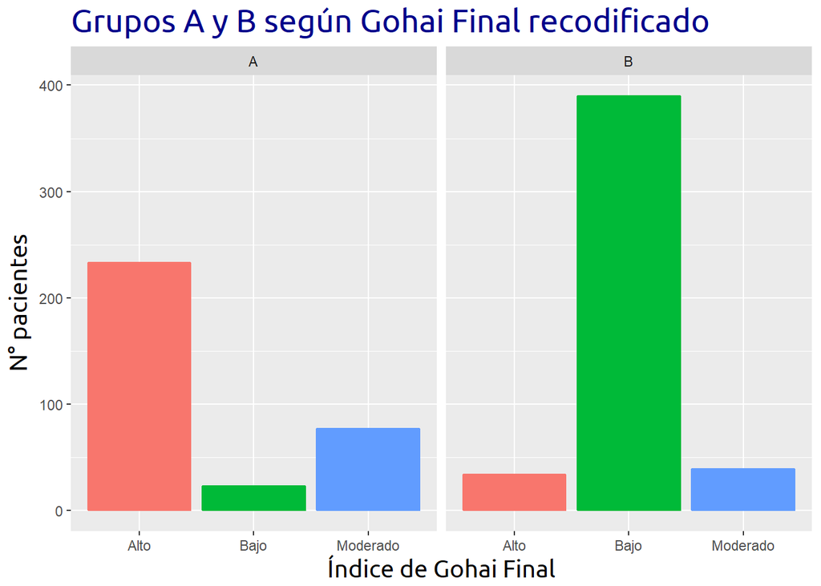

#### BOXPLOT GF*Grupo

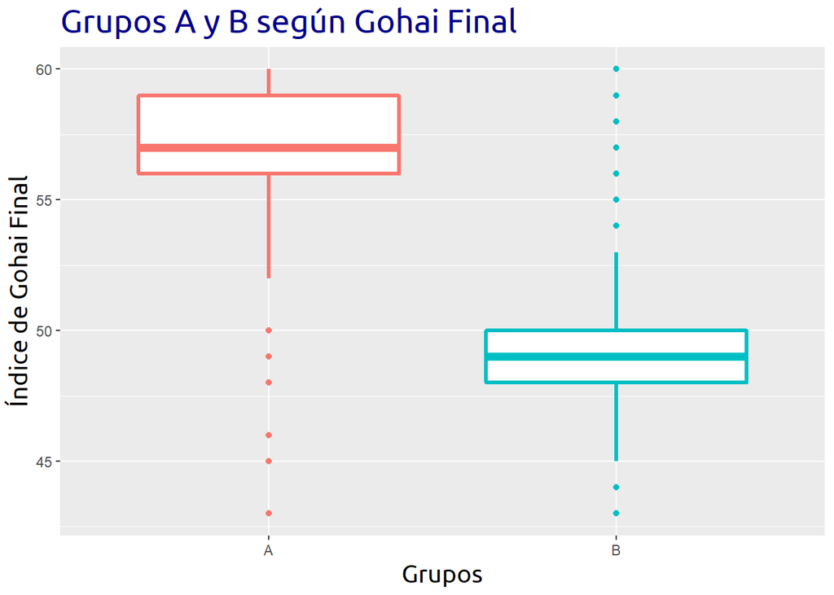

#### BOXPLOT GF*Grupo con jitter

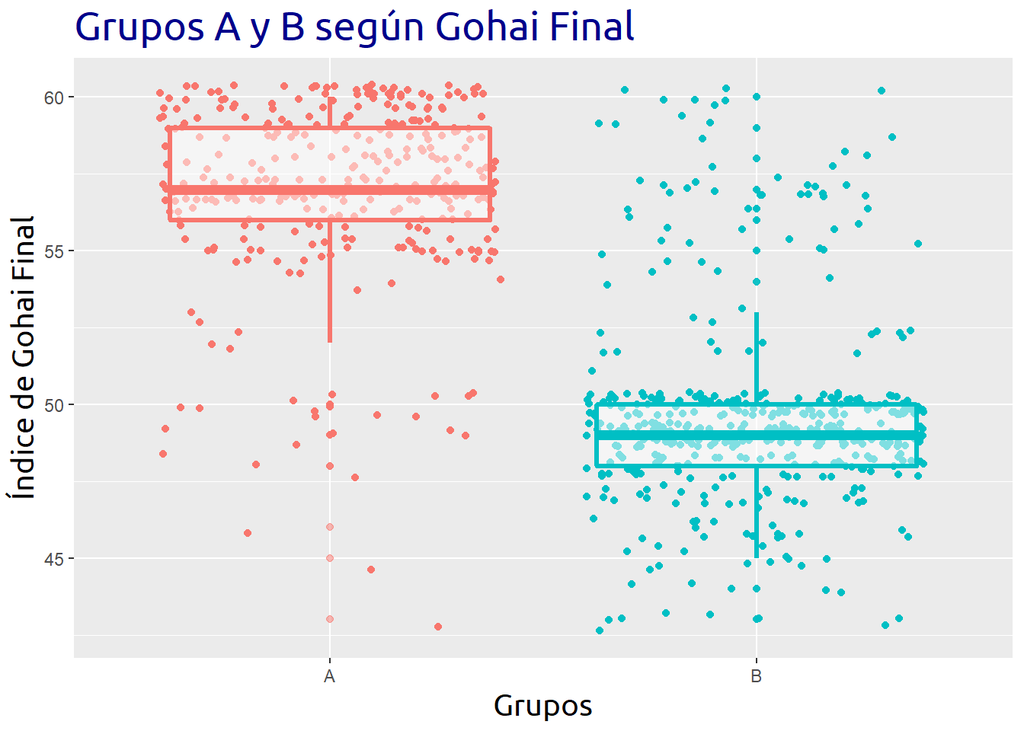

## III. Discusión

El set de datos es robusto, tanto en su cantidad (n=796), como en su cualidad, al poseer indicadores de salud sólidos y altamente informativos. A continuación los análisis que se deben formular:

#### Condición de Salud

La condición de salud se mide a través de tres indicadores: 1) **Eichner**, que mide el grado contacto oclusal. Las clasificadas como A(1) tienen contacto oclusal en las cuatro áreas masticatorias; las clasificadas como B(2) tienen contacto oclusal pero no en todas las áreas masticatorias; y las clasificadas como C(3) no presentan ningún contacto oclusal aunque pueden quedar dientes remanentes.

```
##   1   2   3
## 341 255 200
```

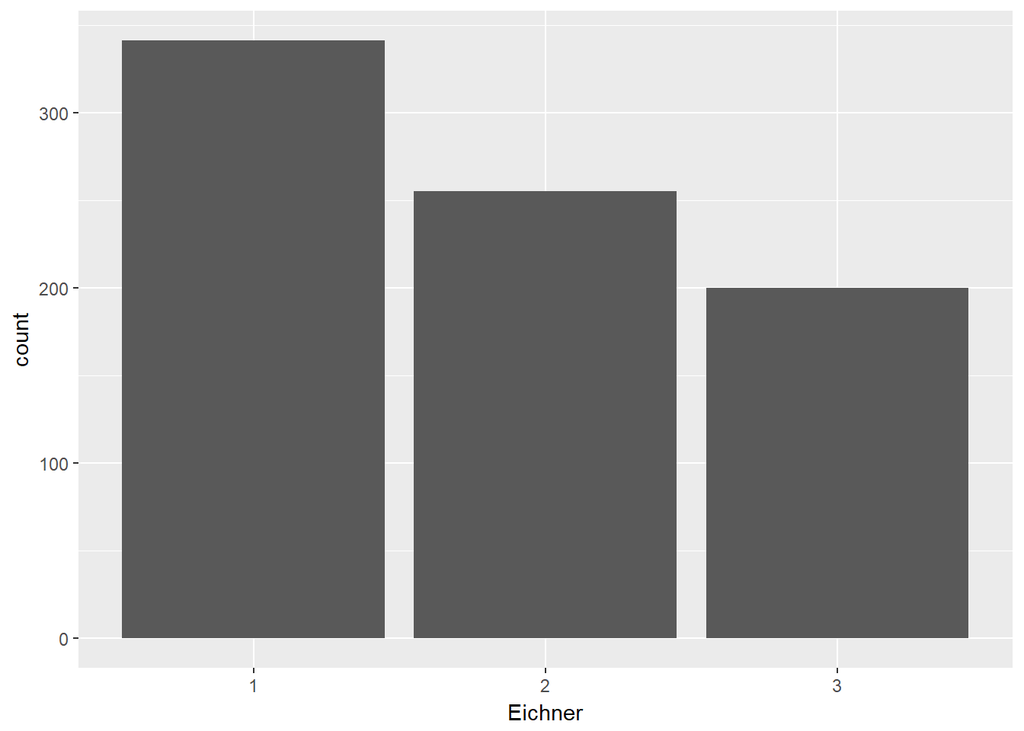

2. **Indice de Gohai**, que tiene dos mediciones, ANTES y DESPUÉS del tratamiento. Es notoria la movilización de 383 individuos, que superaron la condición de Bajo, posicionandose en Moderado y Alto.

```
##    Min. 1st Qu.  Median    Mean 3rd Qu.    Max.
##   34.00   43.00   44.00   44.75   47.00   50.00
```

```
## Bajo
##  796
```

```
##    Min. 1st Qu.  Median    Mean 3rd Qu.    Max.
##   43.00   49.00   50.00   52.77   57.00   60.00
```

```
##     Alto     Bajo Moderado
##      267      413      116
```

3. **Adherencia**, que mide la adherencia al tratamiento protésico. Aquí también es notorio el cambio de Sí a No, que identifica a 433 individuos.

```
##  Si
## 796
```

```
##  No  Si
## 433 363
```

#### Género y Condición de Salud

La muestra se compone mayoritariamente por individuos femeninos.

```
##   0   1
## 238 558
```

Si comparamos la edad según género obtenemos

```
##        0        1
## 79.39076 77.94982
```

## IV. Conclusiones

[figure not shown]